# Assignment 5

Brian Yim

2025-11-22

# First, I set all the working environment (libraries)

```r
library(readr)
library(cluster)
library(factoextra)
library(NbClust)
library(FactoMineR)
library(pdist)
library(flexclust)
library(purrr)
```

#Then, I read the data

```r
cereals <- read.csv("C:/Users/hyim/OneDrive - Kent State University/Desktop/64060 Assignment/Cereals.csv")
View(cereals)
```

#Q1. Apply hierarchical clustering to the data using Euclidean distance to the normalized measurements. Use Agnes to compare the clustering from single linkage, complete linkage, average linkage, and Ward. Choose the best method.

#Answer: The most appropriate clustering method can be identified using a numerical indicator of clustering strength, known as the agglomerative coefficient. Of the four methods examined, the Ward’s method produces the strongest clustering structure, with an AC of 0.9046.

```r
row.names(cereals)<-cereals[,1]#set row names to the cereals column
data.frame(colnames(cereals))
```

```
##    colnames.cereals.
## 1               name
## 2                mfr
## 3               type
## 4           calories
## 5            protein
## 6                fat
## 7             sodium
## 8              fiber
## 9              carbo
## 10            sugars
## 11            potass
## 12          vitamins
## 13             shelf
## 14            weight
## 15              cups
## 16            rating
```

#checking any missing data

```r
table(is.na(cereals))
```

```
##
## FALSE  TRUE
##  1228     4
```

```r
mydata<-na.omit(cereals)
table(is.na(mydata))
```

```
##
## FALSE
##  1184
```

#use a data frame contains only variables that are nutritional information, store display, and consumer ratings because they are numeric

```r
mydata<-mydata[,c(4:16)]
```

#scaling the data

```r
scaledmydata<-scale(mydata)
View(scaledmydata)
```

#using Euclidean distance apply hierarchical clustering

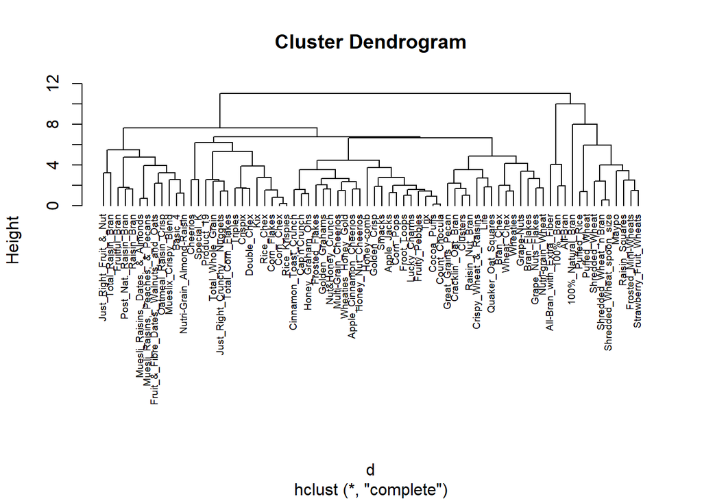

```r
d<-dist(scaledmydata,method="euclidean")
hc_complete<-hclust(d,method="complete")
plot(hc_complete, cex=0.6, hang=-1)
```

#Four linkage methods using Agnes to compare the clustering: Single linkage, Complete linkage, Average linkage (UPGMA), Ward’s method

```r
hc_single<-agnes(d,method="single") #Hierarchical clustering using Single Linkage
hc_single$ac #Agglomerative coefficient of hc_single
```

```
## [1] 0.6067859
```

```r
hc_complete<-agnes(d,method="complete")#Hierarchical clustering using Complete Linkage
hc_complete$ac#Agglomerative coefficient of hc_complete
```

```
## [1] 0.8353712
```

```r
hc_average<-agnes(d,method="average")#Hierarchical clustering using Average Linkage
hc_average$ac#Agglomerative coefficient of hc_average
```

```
## [1] 0.7766075
```

```r
hc_ward<-agnes(d,method="ward")#Hierarchical clustering using Ward's method
hc_ward$ac#Agglomerative coefficient of hc_ward
```

```
## [1] 0.9046042
```

#Q2. How many clusters would you choose?